[figure not shown]

# Grado de Ciencia de Datos.

## Práctica 2. Extracción de características y división de conjuntos.

#### Yolanda Vives Gilabert, Álvaro Moreno Martínez, Marcelino Martínez Sober,

Andreu Cantó y Amparo Gálvez

## 2.1. Análisis en Componentes Principales (PCA).

### 2.1.1 PCA "a mano"

#### Cargamos librerías

```python
from sklearn import datasets
import matplotlib.pyplot as plt
import pandas as pd
%matplotlib inline
import numpy as np
from IPython.display import Markdown as md
from sklearn import preprocessing
```

```python
#Generamos una distribución lineal de puntos y lo metemos en el dataframe spotify.csv. Sentiros libres de volver
# a generarlo con diferentes parámetros para fastidiar...

from sklearn.datasets import make_regression
X, y = make_regression(n_samples=2000, n_features=1, n_informative=1, n_targets=1,
                       noise=30, random_state=1234)

y=y+300
y.shape[0]
y.reshape(y.shape[0],1)
a=np.column_stack((X,y))

a.shape
pd.DataFrame(a,columns=['Guitar_power','Quality']).to_csv('spotify.csv')
```

**Ejercicio.** Carga el fichero de spotify llamado `spotify.csv` y representa la variable `Guitar_power` vs. `Quality`.

```python
df = pd.read_csv('spotify.csv', index_col = 0)
```

```
      Guitar_power     Quality
0         0.632579  361.109822
1         1.591464  397.109251
2        -0.894868  236.792901
3        -1.567717  181.358459
4        -0.423006  330.161002
...            ...         ...
1995      0.469549  362.292447
1996     -0.653630  261.298343
1997     -0.368925  246.918683
1998     -1.312713  245.794054
1999     -1.085523  193.086191

[2000 rows x 2 columns]
```

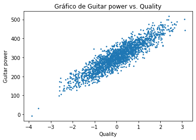

```python
plt.scatter(df['Guitar_power'],df['Quality'], s=3)
plt.title('Gráfico de Guitar power vs. Quality')
plt.xlabel('Quality')
plt.ylabel('Guitar power')
print(df)
```

#### Empezamos con el cálculo de PCA paso a paso.

**Ejercicio.** Estandariza las dos variables presentes en el problema. Representa de nuevo el gráfico anterior con las variables estandarizadas.

```python
#No olvides convertir el dataframe a array
X=np.array(df)

Xstd = preprocessing.scale(X)
```

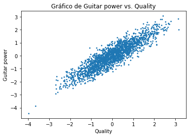

```python
plt.scatter(Xstd[:,0], Xstd[:,1], s=3)
plt.title('Gráfico de Guitar power vs. Quality')
plt.xlabel('Quality')
plt.ylabel('Guitar power')
```

#### Calculamos la matriz de covarianza

```python
Xm = Xstd.copy()

cov_matrix = np.dot(Xm.T, Xm) / Xm.shape[0]
```

```python
# Esta es la matriz de covarianza
cov_matrix
```

```
array([[1.        , 0.90088747],
       [0.90088747, 1.        ]])
```

#### Obtenemos los autovalores y autovectores de la matriz de covarianza

```python
evals, evecs = np.linalg.eig(cov_matrix)
```

Los vectores de la base del nuevo espacio vectorial....

```python
#Autovectores
evecs
```

```
array([[-0.70710678, -0.70710678],
       [ 0.70710678, -0.70710678]])
```

La varianza explicada por cada componente principal

```python
#Autovalores
evals
```

```
array([0.09911253, 1.90088747])
```

#### A continuación ordenaremos los autovectores por orden de autovalor, de mayor a menor

```python
# Ordenamos los autovectores de mayor a menor autovalor
idx = np.argsort(-evals)
evecs = evecs[:,idx]
```

**Ejercicio.** Calcula la varianza explicada acumulada por cada componente principal porcentualmente.

```python
#Ordenamos los autovalores para comprobar el porcentaje de varianza explicada por cada PC
evals = np.sort(evals)[::-1]

varianza_total = np.sum(evals)
varianza_explicada = (evals / varianza_total) * 100

varianza_explicada_acumulada = np.cumsum(varianza_explicada)

print('La varianza explicada acumulada es: ', varianza_explicada_acumulada)
```

```
La varianza explicada acumulada es:  [ 95.0443733 100.       ]
```

```python
a = varianza_explicada_acumulada.round(2)[0]

md("Observamos que con la primera componente principal explicamos el {}% de \
la varianza del problema... Conclusión, con una variable explicamos el problema \
planteado!".format(a))
```

Observamos que con la primera componente principal explicamos el 95.04% de la varianza del problema... Conclusión, con una variable explicamos el problema planteado!